# Bangalore’s rain arrived in bursts, not evenly across days

Codex

2026-10-02

## The question

The heatmap showed *where* rain fell. This follow-up asks a different question: was each locality’s seasonal rain spread fairly evenly across days, or did a small number of wet days account for most of its total?

The unit is a complete locality-day from the WeatherUnion hourly archive. For each station, daily values are sorted from wettest to driest, then converted to two cumulative percentages:

- x = the share of complete days included, in descending daily-rain order;
- y = the share of that locality’s total rain accumulated by those days.

A straight diagonal would mean rainfall was uniform across days. Curves above it mean concentration: the first few wettest days account for more than their proportional share of seasonal rain. Dry days remain in the denominator, so this is a daily-rain distribution, not only a rainy-day intensity curve.

## Coverage first

```r
archive <- open_dataset(file.path(root_dir, "data", "weatherunion_bengaluru_hourly.parquet"))
hourly <- archive %>%
  filter(
    hour_ist >= as.POSIXct("2026-05-01 00:00:00", tz = "Asia/Kolkata"),
    hour_ist < as.POSIXct("2026-10-01 00:00:00", tz = "Asia/Kolkata")
  ) %>%
  select(locality_id, current_locality_name, hour_ist, rain_mm) %>% collect() %>%
  mutate(date = as.Date(hour_ist, tz = "Asia/Kolkata"))

stopifnot(!anyDuplicated(hourly[c("locality_id", "hour_ist")]))
stopifnot(all(hourly$rain_mm >= 0 | is.na(hourly$rain_mm)))

daily_raw <- hourly %>%
  group_by(locality_id, current_locality_name, date) %>%
  summarise(
    observed_hours = n(),
    valid_rain_hours = sum(!is.na(rain_mm)),
    rain_mm = sum(rain_mm, na.rm = TRUE),
    .groups = "drop"
  ) %>%
  mutate(rain_mm = if_else(valid_rain_hours == 24, rain_mm, NA_real_))

coverage <- daily_raw %>%
  summarise(
    complete_days = sum(!is.na(rain_mm)),
    first_day = min(date), last_day = max(date), .by = c(locality_id, current_locality_name)
  ) %>% arrange(desc(complete_days), current_locality_name)

coverage
```

```
## # A tibble: 31 × 5
##    locality_id current_locality_name complete_days first_day  last_day
##    <chr>       <chr>                         <int> <date>     <date>
##  1 ZWL005576   BIAL Airport Road               153 2026-05-01 2026-09-30
##  2 ZWL003467   Banashankari                    153 2026-05-01 2026-09-30
##  3 ZWL004924   Bannerghatta Road               153 2026-05-01 2026-09-30
##  4 ZWL004164   Bellandur                       153 2026-05-01 2026-09-30
##  5 ZWL008797   Devanahalli                     153 2026-05-01 2026-09-30
##  6 ZWL006274   Electronic City                 153 2026-05-01 2026-09-30
##  7 ZWL001196   HSR Layout                      153 2026-05-01 2026-09-30
##  8 ZWL001273   Indiranagar                     153 2026-05-01 2026-09-30
##  9 ZWL005530   JP Nagar                        153 2026-05-01 2026-09-30
## 10 ZWL003159   Jalahalli                       153 2026-05-01 2026-09-30
## # ℹ 21 more rows
```

The main comparison retains the 28 stations with at least 120 complete days, matching the previous heatmap. Three shorter/incomplete records remain visible in the coverage table but are not ranked as if they represented the full May-September window.

## Pareto curves

```r
selected <- coverage %>% filter(complete_days >= 120) %>% pull(current_locality_name)

pareto <- daily_raw %>%
  filter(current_locality_name %in% selected, !is.na(rain_mm)) %>%
  group_by(current_locality_name) %>%
  arrange(desc(rain_mm), date, .by_group = TRUE) %>%
  mutate(
    day_share = row_number() / n() * 100,
    rain_share = cumsum(rain_mm) / sum(rain_mm) * 100,
    seasonal_rain_mm = sum(rain_mm),
    rainy_days = sum(rain_mm > 0),
    n_days = n()
  ) %>% ungroup()

facts <- pareto %>%
  group_by(current_locality_name, seasonal_rain_mm, rainy_days, n_days) %>%
  summarise(
    rain_top_1pct = approx(day_share, rain_share, xout = 1, rule = 2)$y,
    rain_top_5pct = approx(day_share, rain_share, xout = 5, rule = 2)$y,
    rain_top_10pct = approx(day_share, rain_share, xout = 10, rule = 2)$y,
    rain_top_20pct = approx(day_share, rain_share, xout = 20, rule = 2)$y,
    .groups = "drop"
  ) %>% arrange(desc(rain_top_10pct))
facts
```

```
## # A tibble: 28 × 8
##    current_locality_name seasonal_rain_mm rainy_days n_days rain_top_1pct
##    <chr>                            <dbl>      <int>  <int>         <dbl>
##  1 Brookefields                      289.         30    139          17.3
##  2 Mahadevapura                      432.         52    153          17.6
##  3 Rajajinagar                       570.         62    149          16.5
##  4 Aavalahalli                       341          60    150          20.2
##  5 RT Nagar                          486.         66    153          18.9
##  6 Kammanahalli                      595          50    150          14.7
##  7 KR Puram                          540.         65    153          15.4
##  8 Jalahalli                         230.         53    153          19.6
##  9 Nagavara                          672.         58    153          23.5
## 10 MG Road                           702          75    153          14.7
## # ℹ 18 more rows
## # ℹ 3 more variables: rain_top_5pct <dbl>, rain_top_10pct <dbl>,
## #   rain_top_20pct <dbl>
```

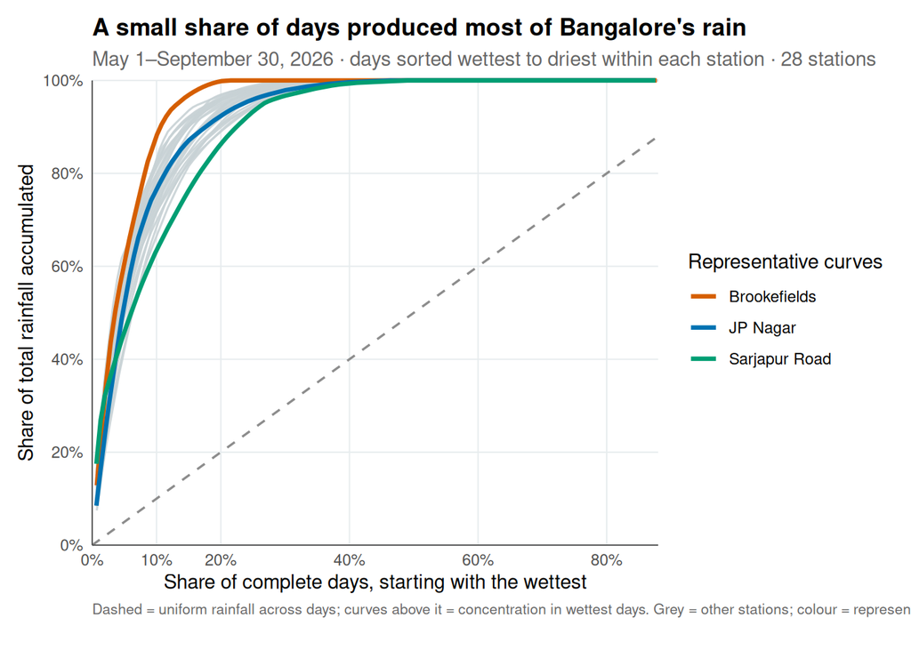

```r
# Label the wettest, driest and median-concentration curves; all curves remain drawn.
label_names <- facts %>%
  mutate(rank_concentration = rank(rain_top_10pct, ties.method = "first")) %>%
  filter(current_locality_name %in% c(
    facts$current_locality_name[1],
    facts$current_locality_name[nrow(facts)],
    facts$current_locality_name[ceiling(nrow(facts) / 2)]
  )) %>% pull(current_locality_name)

plot_lines <- pareto %>% mutate(
  curve = if_else(current_locality_name %in% label_names, current_locality_name, "Other localities")
)

pareto_path <- file.path(chart_dir, "bangalore-rain-variation-2026-pareto-curves.png")
pareto_plot <- ggplot(plot_lines, aes(day_share, rain_share, group = current_locality_name)) +
  geom_abline(slope = 1, intercept = 0, linetype = "dashed", linewidth = 0.6, colour = "#8C8C8C") +
  geom_line(data = plot_lines %>% filter(curve == "Other localities"), colour = "#C7D1D5", linewidth = 0.55, alpha = 0.9) +
  geom_line(data = plot_lines %>% filter(curve != "Other localities"), aes(colour = current_locality_name), linewidth = 1.15) +
  scale_colour_manual(values = setNames(c("#D55E00", "#0072B2", "#009E73")[seq_along(label_names)], label_names), name = "Representative curves") +
  scale_x_continuous(limits = c(0, 88), breaks = c(0, 10, 20, 40, 60, 80), labels = label_percent(scale = 1), expand = c(0, 0)) +
  scale_y_continuous(limits = c(0, 100), breaks = c(0, 20, 40, 60, 80, 100), labels = label_percent(scale = 1), expand = c(0, 0)) +
  labs(
    title = "A small share of days produced most of Bangalore's rain",
    subtitle = "May 1–September 30, 2026 · days sorted wettest to driest within each station · 28 stations",
    x = "Share of complete days, starting with the wettest",
    y = "Share of total rainfall accumulated",
    caption = "Dashed = uniform rainfall across days; curves above it = concentration in wettest days. Grey = other stations; colour = representative curves. WeatherUnion observations."
  ) +
  coord_cartesian(clip = "off") +
  theme_minimal(base_size = 11) +
  theme(
    panel.grid.minor = element_blank(),
    panel.grid.major = element_line(colour = "#E7ECEE", linewidth = 0.35),
    axis.line = element_line(colour = "#555555", linewidth = 0.35),
    plot.title = element_text(face = "bold"),
    plot.subtitle = element_text(colour = "#666666"),
    plot.caption = element_text(colour = "#666666", size = 8, hjust = 0),
    plot.margin = margin(10, 10, 18, 10)
  )
pareto_plot
```

```r
ggsave(pareto_path, pareto_plot, width = 10.5, height = 7.4, dpi = 180, bg = "white")
```

## What it says

```r
top <- facts %>% summarise(
  top10 = median(rain_top_10pct),
  top20 = median(rain_top_20pct),
  top5 = median(rain_top_5pct),
  min10 = min(rain_top_10pct), max10 = max(rain_top_10pct)
)
cat(sprintf("Across the 28 stations, the median wettest 10%% of complete days contributed %.1f%% of the season's rain; the median wettest 20%% contributed %.1f%%. At the station level, the top-10%% share ranged from %.1f%% to %.1f%%. These curves are therefore strongly bowed above the uniform diagonal, rather than close to a straight line.\n", top$top10, top$top20, top$min10, top$max10))
```

Across the 28 stations, the median wettest 10% of complete days contributed 76.3% of the season’s rain; the median wettest 20% contributed 94.0%. At the station level, the top-10% share ranged from 63.4% to 88.0%. These curves are therefore strongly bowed above the uniform diagonal, rather than close to a straight line.

## Verdict

Insightful: yes

The Pareto view adds a useful second dimension to the heatmap: Bangalore’s seasonal rain was not only spatially uneven, it was temporally concentrated. The main result is that a small fraction of wettest days generated a disproportionate share of each station’s total, while the spread between curves shows that concentration itself varied by locality. This is suitable as a follow-up chart to the existing unpublished Substack draft, but the source remains one WeatherUnion season and 28 station records rather than a city-wide interpolated rainfall field.

**Chart:** `docs/assets/analysis/bangalore-rain-variation-2026-pareto-curves.png`

**Blog/Substack:** not modified. This is a draft analysis from chat; remote draft editing requires explicit approval.